# Competition for day 5

# 병원 개/폐업 예측하기

**출처** : https://dacon.io/competitions/official/9565/overview/

**(( 데이콘 DACON 대회 참고))**

**대회 및 데이터 설명**

학습 데이터와 테스트 데이터는 다음과 같이 구성된다.

```r
load("C:/Users/sec/Desktop/개인 업무 자료/DRA/R 캠프 앙상블/day5Data.RData")
```

```r
str(tr)
```

```
## 'data.frame':    301 obs. of  58 variables:
##  $ inst_id           : int  1 3 4 7 9 11 14 15 16 17 ...
##  $ OC                : Factor w/ 2 levels " close","open": 2 2 2 2 2 2 2 2 2 2 ...
##  $ sido              : Factor w/ 16 levels "busan","choongbuk",..: 3 10 9 11 10 10 9 1 13 15 ...
##  $ sgg               : int  73 32 89 141 32 155 169 66 91 4 ...
##  $ openDate          : int  20071228 19970401 20161228 20000814 20050901 20020501 19820702 19871102 20060922 20000124 ...
##  $ bedCount          : int  175 410 468 353 196 243 213 250 280 55 ...
##  $ instkind          : Factor w/ 8 levels "","clinic","dental_clinic",..: 6 4 6 4 4 4 4 4 6 4 ...
##  $ revenue1          : num  4.22e+09 NA 1.00e+09 7.25e+10 4.90e+10 ...
##  $ salescost1        : num  0.00 NA 5.15e+08 0.00 0.00 ...
##  $ sga1              : num  3.96e+09 NA 4.47e+08 7.07e+10 4.77e+10 ...
##  $ salary1           : num  2.03e+09 NA 2.96e+08 3.18e+10 2.45e+10 ...
##  $ noi1              : num  1.57e+07 NA 7.62e+04 5.06e+08 1.12e+08 ...
##  $ noe1              : num  1.52e+07 NA 3.00e+04 1.26e+09 1.42e+09 ...
##  $ interest1         : num  1.32e+07 NA 0.00 1.20e+09 1.31e+09 ...
```

[output cut: 44 more lines]

```r
str(te)
```

```
## 'data.frame':    127 obs. of  58 variables:
##  $ inst_id           : int  2 5 6 8 10 12 13 20 21 23 ...
##  $ OC                : logi  NA NA NA NA NA NA ...
##  $ sido              : Factor w/ 15 levels "busan","choongbuk",..: 9 10 12 1 11 7 7 11 6 7 ...
##  $ sgg               : int  139 149 103 71 26 122 31 147 95 169 ...
##  $ openDate          : int  19981125 20160309 19890427 20100226 20040604 20081224 20020513 20070110 20151209 19851223 ...
##  $ bedCount          : int  300 44 276 363 213 220 370 246 148 27 ...
##  $ instkind          : Factor w/ 7 levels "","clinic","general_hospital",..: 3 4 3 3 3 3 3 3 5 4 ...
##  $ revenue1          : num  6.68e+10 3.50e+10 2.33e+10 0.00 5.04e+10 ...
##  $ salescost1        : num  0.00 0.00 2.54e+09 0.00 0.00 ...
##  $ sga1              : num  6.57e+10 3.26e+10 2.31e+10 0.00 4.86e+10 ...
##  $ salary1           : num  3.22e+10 1.67e+10 1.17e+10 0.00 2.30e+10 ...
##  $ noi1              : num  4.31e+09 6.87e+07 1.60e+09 4.85e+09 1.53e+09 ...
##  $ noe1              : num  4.90e+09 1.98e+09 1.38e+09 2.06e+09 0.00 ...
##  $ interest1         : num  1.78e+09 1.94e+09 8.10e+08 0.00 2.57e+09 ...
```

[output cut: 44 more lines]

## EDA & Feature Engineering

우선 두 데이터에 각각 factor형의 변수들이 있음을 확인할 수 있다.

**factor형 변수의 경우 level이 어떠한 지를 먼저 확인하는 과정이 중요하다**

또한 employee1, 2변수를 보면

train에는 int형 변수이지만 test에는 factor형 변수임을 확인할 수 있다.

이 경우 test 데이터의 employee1, 2를 int형으로 바꾸는 과정을 거친다.

factor 데이터 type 확인

sido 변수의 경우

```r
table(tr$sido)
```

```
##
##     busan choongbuk choongnam     daegu   daejeon   gangwon   gwangju gyeongbuk
##        26        13        23        14        13        10         2        39
##  gyeonggi gyeongnam   incheon   jeonbuk   jeonnam    sejong     seoul     ulsan
##        49        35        10        18        21         1        19         8
```

```r
table(te$sido)
```

```
##
##     busan choongbuk choongnam     daegu   daejeon gyeongbuk  gyeonggi gyeongnam
##        17         8         7         3         1        19        19        11
##   incheon      jeju   jeonbuk   jeonnam    sejong     seoul     ulsan
##         4         3        13         8         1         8         5
```

ganwon, gwangju는 학습 데이터에만, jeju는 테스트 데이터에만 존재함을 확인할 수 있다.

instkind의 경우

dental_clinic은 train에만 있고 test에는 없다.

"" 공란의 level도 하나 존재한다.

```r
table(tr$instkind)
```

```
##
##                                    clinic        dental_clinic
##                    1                   18                    1
##     general_hospital             hospital     nursing_hospital
##                   37                   88                  144
##   traditional_clinic traditional_hospital
##                    4                    8
```

```r
table(te$instkind)
```

```
##
##                                    clinic     general_hospital
##                    2                    4                   19
##             hospital     nursing_hospital   traditional_clinic
##                   36                   63                    2
## traditional_hospital
##                    1
```

ownerChagne 변수의 경우 level이 동일함을 확인할 수 있다.

```r
table(tr$ownerChange)
```

```
##
## change   same
##     42    247
```

```r
table(te$ownerChange)
```

```
##
## change   same
##     11    101
```

이렇게 레벨이 각각 상이한 경우에는 **level들을 다 통일해줘야** 한다. 모든 경우를 다 포함하는 합집합의 level를 공통 레벨로 삼게 한다.

```r
Sido <- c("busan", "choongbuk", "choongnam","daegu","daejeon","gangwon","gwangju","gyeongbuk","gyeonggi","gyeongnam","incheon",
          "jeonbuk","jeonnam","sejong","seoul","ulsan","jeju")

Instkind <- c("", "clinic", "dental_clinic", "general_hospital","hospital","nursing_hospital","traditional_clinic","traditional_hospital")
```

```r
tr$sido <- factor(tr$sido, levels = Sido)
te$sido <- factor(te$sido, levels= Sido)

tr$instkind <- factor(tr$instkind, levels= Instkind)
te$instkind <- factor(te$instkind, levels=Instkind)
```

factor로 되어있었던 employee변수를 살펴본다

```r
head(te$employee1)
```

```
## [1] 693 379     760 437 386
## 101 Levels:  1,065 1,637 1,816 100 104 106 107 109 110 111 116 120 121 ... 96
```

```r
head(te$employee2)
```

```
## [1] 693 371     760 385 397
## 98 Levels:  0 1,065 1,104 1,547 100 103 108 109 111 112 117 120 121 125 ... 98
```

보면 ’,’가 들어가 있는 수들이 있음을 확인할 수 있다.

이 경우 level의 이름으로 되어 있는 경우는 반드시 ’,’를 제거해야하는 전처리를 거쳐야 한다.

예를 들어보자

```r
a <- as.factor("1,234")
a
```

```
## [1] 1,234
## Levels: 1,234
```

```r
a <- as.numeric(a)
a
```

```
## [1] 1
```

저러한 factor형 변수 그대로 numeric으로 바꾸게 되면 왜곡된 값이 나타날 수 있다.

’,’를 제거하는 전처리는 다음과 같다.

```r
te$employee1 <- gsub(",", "", te$employee1)
te$employee2 <- gsub(",", "", te$employee2)
te$employee1 <- as.integer(te$employee1)
te$employee2 <- as.integer(te$employee2)
```

factor형 변수에 대한 전처리를 마쳤으면

그 다음으로는, **결측치**에 대한 정보를 알아본다

```r
colSums(is.na(tr))
```

```
##            inst_id                 OC               sido                sgg
##                  0                  0                  0                  0
##           openDate           bedCount           instkind           revenue1
##                  0                  5                  0                  8
##         salescost1               sga1            salary1               noi1
##                  8                  8                  8                  8
##               noe1          interest1              ctax1            profit1
##                  8                  8                  8                  8
##       liquidAsset1        quickAsset1       receivableS1    inventoryAsset1
##                  8                  8                  8                  8
##         nonCAsset1          tanAsset1        OnonCAsset1       receivableL1
##                  8                  8                  8                  8
##              debt1 liquidLiabilities1         shortLoan1     NCLiabilities1
##                  8                  8                  8                  8
##          longLoan1          netAsset1           surplus1           revenue2
##                  8                  8                  8                  8
##         salescost2               sga2            salary2               noi2
##                  8                  8                  8                  8
##               noe2          interest2              ctax2            profit2
##                  8                  8                  8                  8
##       liquidAsset2        quickAsset2       receivableS2    inventoryAsset2
##                  8                  8                  8                  8
##         nonCAsset2          tanAsset2        OnonCAsset2       receivableL2
##                  8                  8                  8                  8
##              debt2 liquidLiabilities2         shortLoan2     NCLiabilities2
##                  8                  8                  8                  8
##          longLoan2          netAsset2           surplus2          employee1
##                  8                  8                  8                 10
##          employee2        ownerChange
##                 13                 12
```

```r
colSums(is.na(te))
```

```
##            inst_id                 OC               sido                sgg
##                  0                127                  0                  0
##           openDate           bedCount           instkind           revenue1
##                  1                  8                  0                  2
##         salescost1               sga1            salary1               noi1
##                  2                  2                  2                  2
##               noe1          interest1              ctax1            profit1
##                  2                  2                  2                  2
##       liquidAsset1        quickAsset1       receivableS1    inventoryAsset1
##                  2                  2                  2                  2
##         nonCAsset1          tanAsset1        OnonCAsset1       receivableL1
##                  2                  2                  2                  2
##              debt1 liquidLiabilities1         shortLoan1     NCLiabilities1
##                  2                  2                  2                  2
##          longLoan1          netAsset1           surplus1           revenue2
##                  2                  2                  2                  2
##         salescost2               sga2            salary2               noi2
##                  2                  2                  2                  2
##               noe2          interest2              ctax2            profit2
##                  2                  2                  2                  2
##       liquidAsset2        quickAsset2       receivableS2    inventoryAsset2
##                  2                  2                  2                  2
##         nonCAsset2          tanAsset2        OnonCAsset2       receivableL2
##                  2                  2                  2                  2
##              debt2 liquidLiabilities2         shortLoan2     NCLiabilities2
##                  2                  2                  2                  2
##          longLoan2          netAsset2           surplus2          employee1
##                  2                  2                  2                  8
##          employee2        ownerChange
##                 15                 15
```

각 관측치별로 NA값의 수를 확인해보면

```r
rowSums(is.na(tr))
```

```
##   [1]  0 48  0  0  0  0  0  0  0  0  0  0  0  0 48  0  0  0  0  0  0  0  0  0  0
##  [26]  0  0  0  0  0  0  0 48  0  0  1  0  0  0  0  0  0  0  0  0  0  0  0  3  0
##  [51]  0  0  0  0  0 48  0  0  0  0 51  0  2  0  0  0  0  0  0  0  0  1  0  0  0
##  [76]  0  0  0  0  0  0  0  0  0  0  0  0  0  0  0  0  0  0  3  0  0  0  0  0  0
## [101]  0  0  0  0  0  0  0  0  0  0  0  0  0  0  0  0  0  0  0  0  0  0  0  0  0
## [126]  0  0  0  0  0  0  0  0  0  0  0  0  0  0  0  0  0  0  0  0  0  0  0  0  0
## [151]  0  0  0  0  0  0  0  0  0  0  0  0  0  0  0  0  0  0  0  0  0  0  0  0  0
## [176]  0  0  0  0  0  0  0  0  0  0  0  0  0  0  0  0  0  0  1  0  0  0  0  0  0
## [201]  0  0  0  0  0  0  2  0  0  0  0  0  3  0  0  0  0  0  0  0  0  0  0  0  0
## [226]  0  0  0  0  0  1  0  0  0  0  0  0  0  0  0  0  0  3  0  0  0  0  0 48  0
## [251]  0  0  0  0  0  0  0 48 51  0  0  0  0  3  0  0  0  0  0  0  0  0  0  0  0
## [276]  0  0  0  0  0  0  0  0  0  0  3  0  0  0  0  0  0  0  0  0  0  0  1  4  2
## [301]  1
```

```r
rowSums(is.na(te))
```

```
##   [1]  1  1  4  1  1  1  1  1  1  1  2  1  1  3  1 49  1  1  1  1  3  1  5  1  1
##  [26]  1  1  1  1  1  1  1  1  1  1  1  1  1  1  1  2  1  1  1  1  1  1  1  1  1
##  [51]  1  1  4  1  1  1 49  1  1  1  1  1  1  1  1  1  1  1  1  1  1  1  1  1  1
##  [76]  1  1  1  2  1  1  1  3  3  2  1  1  1  4  1  1  1  1  4  1  1  1  1  1  3
## [101]  1  1  1  1  3  1  1  1  1  1  1  1  3  3  1  1  1  1  1  1  2  1  3  2  4
## [126]  2  4
```

학습 데이터의 경우 48개, 51개의 거의 전부 NA로 구성된 관측치가 있다 이런 경우 관측치에 대한 정보가 거의 없다고 봐도 무관하므로 제거하도록 한다.

```r
tr <- tr[rowSums(is.na(tr))<48,]
```

타겟 변수는 수치형태로 전환한다. (최종 제출의 포맷을 맞추기 위해)

```r
tr$OC <- ifelse(tr$OC=='open',1,0)
tr$OC <- as.factor(tr$OC)
```

남은 NA값들은 편의상 간단하게 fill로 채우는 과정을 거쳤다.

NA값을 주변 값으로 채우는 함수를 정의한다.

```r
library(tidyr)
fill_na <- function(df, col){
  fill(df, col, .direction='updown') -> df
  return(df)
}
```

남은 NA 수치를 확인하여 해당 변수의 NA들을 주변값으로 메꾼다

```r
colSums(is.na(tr))
```

```
##            inst_id                 OC               sido                sgg
##                  0                  0                  0                  0
##           openDate           bedCount           instkind           revenue1
##                  0                  5                  0                  0
##         salescost1               sga1            salary1               noi1
##                  0                  0                  0                  0
##               noe1          interest1              ctax1            profit1
##                  0                  0                  0                  0
##       liquidAsset1        quickAsset1       receivableS1    inventoryAsset1
##                  0                  0                  0                  0
##         nonCAsset1          tanAsset1        OnonCAsset1       receivableL1
##                  0                  0                  0                  0
##              debt1 liquidLiabilities1         shortLoan1     NCLiabilities1
##                  0                  0                  0                  0
##          longLoan1          netAsset1           surplus1           revenue2
##                  0                  0                  0                  0
##         salescost2               sga2            salary2               noi2
##                  0                  0                  0                  0
##               noe2          interest2              ctax2            profit2
##                  0                  0                  0                  0
##       liquidAsset2        quickAsset2       receivableS2    inventoryAsset2
##                  0                  0                  0                  0
##         nonCAsset2          tanAsset2        OnonCAsset2       receivableL2
##                  0                  0                  0                  0
##              debt2 liquidLiabilities2         shortLoan2     NCLiabilities2
##                  0                  0                  0                  0
##          longLoan2          netAsset2           surplus2          employee1
##                  0                  0                  0                  8
##          employee2        ownerChange
##                 11                 10
```

```r
tr <- fill_na(tr, 'bedCount')
```

```
## Note: Using an external vector in selections is ambiguous.
## i Use `all_of(col)` instead of `col` to silence this message.
## i See <https://tidyselect.r-lib.org/reference/faq-external-vector.html>.
```

```r
tr <- fill_na(tr, 'employee1')
tr <- fill_na(tr, 'employee2')
tr <- fill_na(tr, 'ownerChange')
colSums(is.na(tr))
```

```
##            inst_id                 OC               sido                sgg
##                  0                  0                  0                  0
##           openDate           bedCount           instkind           revenue1
##                  0                  0                  0                  0
##         salescost1               sga1            salary1               noi1
##                  0                  0                  0                  0
##               noe1          interest1              ctax1            profit1
##                  0                  0                  0                  0
##       liquidAsset1        quickAsset1       receivableS1    inventoryAsset1
##                  0                  0                  0                  0
##         nonCAsset1          tanAsset1        OnonCAsset1       receivableL1
##                  0                  0                  0                  0
##              debt1 liquidLiabilities1         shortLoan1     NCLiabilities1
##                  0                  0                  0                  0
##          longLoan1          netAsset1           surplus1           revenue2
##                  0                  0                  0                  0
##         salescost2               sga2            salary2               noi2
##                  0                  0                  0                  0
##               noe2          interest2              ctax2            profit2
##                  0                  0                  0                  0
##       liquidAsset2        quickAsset2       receivableS2    inventoryAsset2
##                  0                  0                  0                  0
##         nonCAsset2          tanAsset2        OnonCAsset2       receivableL2
##                  0                  0                  0                  0
##              debt2 liquidLiabilities2         shortLoan2     NCLiabilities2
##                  0                  0                  0                  0
##          longLoan2          netAsset2           surplus2          employee1
##                  0                  0                  0                  0
##          employee2        ownerChange
##                  0                  0
```

테스트 데이터도 마찬가지의 과정을 거쳐준다.

```r
colnames(te)
```

```
##  [1] "inst_id"            "OC"                 "sido"
##  [4] "sgg"                "openDate"           "bedCount"
##  [7] "instkind"           "revenue1"           "salescost1"
## [10] "sga1"               "salary1"            "noi1"
## [13] "noe1"               "interest1"          "ctax1"
## [16] "profit1"            "liquidAsset1"       "quickAsset1"
## [19] "receivableS1"       "inventoryAsset1"    "nonCAsset1"
## [22] "tanAsset1"          "OnonCAsset1"        "receivableL1"
## [25] "debt1"              "liquidLiabilities1" "shortLoan1"
## [28] "NCLiabilities1"     "longLoan1"          "netAsset1"
## [31] "surplus1"           "revenue2"           "salescost2"
## [34] "sga2"               "salary2"            "noi2"
## [37] "noe2"               "interest2"          "ctax2"
## [40] "profit2"            "liquidAsset2"       "quickAsset2"
## [43] "receivableS2"       "inventoryAsset2"    "nonCAsset2"
## [46] "tanAsset2"          "OnonCAsset2"        "receivableL2"
## [49] "debt2"              "liquidLiabilities2" "shortLoan2"
## [52] "NCLiabilities2"     "longLoan2"          "netAsset2"
## [55] "surplus2"           "employee1"          "employee2"
## [58] "ownerChange"
```

```r
for(i in 3:58){
  te <- fill_na(te, colnames(te)[i])
}

colSums(is.na(te))
```

```
##            inst_id                 OC               sido                sgg
##                  0                127                  0                  0
##           openDate           bedCount           instkind           revenue1
##                  0                  0                  0                  0
##         salescost1               sga1            salary1               noi1
##                  0                  0                  0                  0
##               noe1          interest1              ctax1            profit1
##                  0                  0                  0                  0
##       liquidAsset1        quickAsset1       receivableS1    inventoryAsset1
##                  0                  0                  0                  0
##         nonCAsset1          tanAsset1        OnonCAsset1       receivableL1
##                  0                  0                  0                  0
##              debt1 liquidLiabilities1         shortLoan1     NCLiabilities1
##                  0                  0                  0                  0
##          longLoan1          netAsset1           surplus1           revenue2
##                  0                  0                  0                  0
##         salescost2               sga2            salary2               noi2
##                  0                  0                  0                  0
##               noe2          interest2              ctax2            profit2
##                  0                  0                  0                  0
##       liquidAsset2        quickAsset2       receivableS2    inventoryAsset2
##                  0                  0                  0                  0
##         nonCAsset2          tanAsset2        OnonCAsset2       receivableL2
##                  0                  0                  0                  0
##              debt2 liquidLiabilities2         shortLoan2     NCLiabilities2
##                  0                  0                  0                  0
##          longLoan2          netAsset2           surplus2          employee1
##                  0                  0                  0                  0
##          employee2        ownerChange
##                  0                  0
```

데이터의 openDate(개업 날짜)를 데이터를 살펴보면

```r
head(tr$openDate, 10)
```

```
##  [1] 20071228 20161228 20000814 20050901 20020501 19820702 19871102 20060922
##  [9] 20000124 20080219
```

수치형 데이터로 되어 있는 것을 확인할 수 있다.

날짜 자체의 중요성보다는 병원이 언제쯤 세워졌는 지의 년도 정보만 취해서 factor 변수로 치환

```r
## 개업 날짜 데이터 전처리
tr$openDate <- sapply(tr$openDate, FUN= function(x){as.factor(x%/%10000)})
te$openDate <- sapply(te$openDate, FUN= function(x){as.factor(x%/%10000)})
```

이 역시 level들이 다름을 확인할 수 있다.

```r
levels(tr$openDate)
```

```
##  [1] "2007" "2016" "2000" "2005" "2002" "1982" "1987" "2006" "2008" "2013"
## [11] "1981" "2012" "1994" "1996" "2004" "1997" "2003" "2001" "2014" "2011"
## [21] "1988" "1998" "2009" "2017" "1993" "1983" "2010" "1999" "1985" "2015"
## [31] "1984" "1978" "1989" "1980" "1986" "1992" "1995"
```

```r
levels(te$openDate)
```

```
##  [1] "1998" "2016" "1989" "2010" "2004" "2008" "2002" "2007" "2015" "1985"
## [11] "1982" "2003" "1995" "2000" "2013" "1997" "1999" "2006" "2005" "1994"
## [21] "2014" "1976" "1988" "2012" "2011" "2009" "1993" "1983" "1996" "2017"
## [31] "2001"
```

```r
setdiff(levels(tr$openDate), levels(te$openDate))
```

```
## [1] "1987" "1981" "1984" "1978" "1980" "1986" "1992"
```

```r
setdiff(levels(te$openDate), levels(tr$openDate))
```

```
## [1] "1976"
```

년도 레벨 값을 통일해주는 과정을 거친다.

```r
years <- c( "2007","2016","2000" ,"2005", "2002", "1982", "1987", "2006", "2008", "2013", "1981", "2012", "1994", "1996", "2004", "1997", "2003", "2001", "2014", "2011", "1988",
            "1998", "2009" ,"2017", "1993", "1983", "2010", "1999", "1985", "2015", "1984", "1978", "1989", "1980", "1986", "1992", "1995", "1976")

tr$openDate <- factor(tr$openDate, levels=years)
te$openDate <- factor(te$openDate, levels=years)
```

이런 기본적인 전처리를 마치고

우선 변수들이 타겟 변수(병원의 개/폐업)에 얼마나 영향을 미치는 지를 확인하기 위해

시각화하는 과정을 거친다

우선 factor변수들의 경우를 제외하고

수치형 변수의 영향력을 나타내기 위한 시각화 과정을 거친다

```r
# factor 변수인 -- sido, openDate, instkind, ownerChange 제외하고 전부 gather로 묶어서 정리
trim_tr <- tr[,c(-1,-3,-5,-7,-58)]
library(dplyr)
trim_tr %>% gather(key=variable, value, -OC) -> gather_tr
head(gather_tr, 10)
```

```
##    OC variable value
## 1   1      sgg    73
## 2   1      sgg    89
## 3   1      sgg   141
## 4   1      sgg    32
## 5   1      sgg   155
## 6   1      sgg   169
## 7   1      sgg    66
## 8   1      sgg    91
## 9   1      sgg     4
## 10  1      sgg    92
```

```r
library(ggplot2)
## 피처의 전반적인 특징을 확인할 수 있다..!
gather_tr %>% ggplot(aes(x=OC,y=value))+facet_wrap(~variable, scales='free') + geom_boxplot()
```

[output not shown]

또한 시각화로 변수 간의 관계를 확인해볼 수 있다.

```r
library(corrplot)
# OC 항목 제거
trim_tr <- trim_tr[,-1]
cors <- cor(trim_tr)
corrplot(cors)
```

[output not shown]

수치형 변수가 아닌 factor 형 변수의 영향력도 확인할 수 있다.

```r
table(tr$sido, tr$OC)
```

```
##
##              0  1
##   busan      1 25
##   choongbuk  0 13
##   choongnam  1 21
##   daegu      0 14
##   daejeon    0 13
##   gangwon    0  9
##   gwangju    0  2
##   gyeongbuk  2 36
##   gyeonggi   5 42
##   gyeongnam  0 34
##   incheon    0  9
##   jeonbuk    2 16
##   jeonnam    3 18
##   sejong     0  1
##   seoul      1 18
##   ulsan      0  7
##   jeju       0  0
```

```r
table(tr$openDate, tr$OC)
```

```
##
##         0  1
##   2007  2 19
##   2016  0  8
##   2000  0  5
##   2005  2 10
##   2002  0  8
##   1982  0  5
##   1987  0  3
##   2006  0 15
##   2008  0 28
##   2013  1 12
##   1981  0  2
##   2012  1 14
##   1994  0  3
```

[output cut: 25 more lines]

```r
table(tr$instkind, tr$OC)
```

```
##
##                          0   1
##                          1   0
##   clinic                 1  16
##   dental_clinic          0   1
##   general_hospital       1  32
##   hospital               5  83
##   nursing_hospital       5 136
##   traditional_clinic     1   3
##   traditional_hospital   1   7
```

```r
table(tr$ownerChange, tr$OC)
```

```
##
##            0   1
##   change   7  38
##   same     8 240
```

또한 변수를 추가할 수도 있는데

또한 2016년과 2017년 간의 수익의 차이를 나타내는 revenue0이라는 변수를 하나 추가한다

```r
#수익 차 변수 추가
tr$revenue0 <- tr$revenue1 - tr$revenue2
te$revenue0 <- te$revenue1 - te$revenue2
```

마찬가지로 이윤의 차이를 나타내는 profit0라는 변수도 추가한다.

```r
tr$profit0 <- tr$profit1 - tr$profit2
te$profit0 <- te$profit1 - te$profit2
```

formula 구성

```r
#설명 변수 column들
name <- names(tr)[3:ncol(tr)]
fomula2 <- as.formula(paste('OC',paste(name,collapse='+'),sep='~'))
fomula2
```

```
## OC ~ sido + sgg + openDate + bedCount + instkind + revenue1 +
##     salescost1 + sga1 + salary1 + noi1 + noe1 + interest1 + ctax1 +
##     profit1 + liquidAsset1 + quickAsset1 + receivableS1 + inventoryAsset1 +
##     nonCAsset1 + tanAsset1 + OnonCAsset1 + receivableL1 + debt1 +
##     liquidLiabilities1 + shortLoan1 + NCLiabilities1 + longLoan1 +
##     netAsset1 + surplus1 + revenue2 + salescost2 + sga2 + salary2 +
##     noi2 + noe2 + interest2 + ctax2 + profit2 + liquidAsset2 +
##     quickAsset2 + receivableS2 + inventoryAsset2 + nonCAsset2 +
##     tanAsset2 + OnonCAsset2 + receivableL2 + debt2 + liquidLiabilities2 +
##     shortLoan2 + NCLiabilities2 + longLoan2 + netAsset2 + surplus2 +
##     employee1 + employee2 + ownerChange + revenue0 + profit0
```

모든 피처들을 집어 넣은 randomForest 모델을 돌린 뒤 피처의 중요도를 확인해본다

```r
library(randomForest)
```

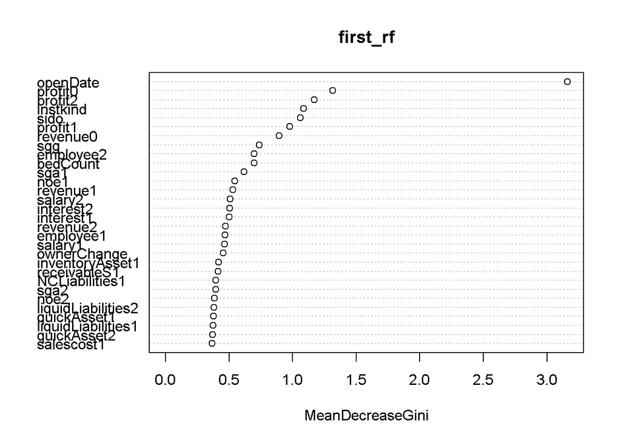

```r
set.seed(10)
first_rf <- randomForest(fomula2, tr)
varImpPlot(first_rf)
```

submission 할 데이터 셋 확인

```r
head(sub, 10)
```

```
##    inst_id OC
## 1        2  0
## 2        5  0
## 3        6  0
## 4        8  0
## 5       10  0
## 6       12  0
## 7       13  0
## 8       20  0
## 9       21  0
## 10      23  0
```